# GBSG2 Exploration

Sep Dadsetan

4/10/2019

### Description

The German Breast Cancer Study Group 2 (GBSG2) is a dataset consisting of 686 female breast cancer observations with 10 features (see below). Goal of this document will be to characterize the dataset and apply verious machine learning algorithms to help us predict the length of time which future patients may reach a censoring event.

#### Feature Descriptions

- **horTh**: hormonal therapy, a factor at two levels no and yes.
- **age**: of the patients in years.
- **menostat**: menopausal status, a factor at two levels `pre` (premenopausal) and `post` (postmenopausal).
- **tsize**: tumor size (in mm).
- **tgrade**: tumor grade, a ordered factor at levels `I < II < III`.
- **pnodes**: number of positive nodes.
- **progrec**: progesterone receptor (in fmol).
- **estrec**: estrogen receptor (in fmol).
- **time**: recurrence free survival time (in days).
- **cens**: censoring indicator (0- censored, 1- event)

### Load Data

```r
data("GBSG2", package = "TH.data")
gbsg2 <- GBSG2 %>% as_tibble() %>% clean_names()
```

### Explore Characteristics

Let’s take a look at characteristics like dimension, feature, missingness, distribution, etc. As we stated above there are 686 observations x 10 features. `hor_th` and `menostat` are factors, `tgrade` is an ordinal, and the rest are integers.

```r
# Print head of tibble so we can look at a few values
head(gbsg2) %>%
  kable() %>%
  kable_styling(bootstrap_options = c("striped", "hover", "responsive"))
```

| hor_th | age | menostat | tsize | tgrade | pnodes | progrec | estrec | time | cens |
| --- | --- | --- | --- | --- | --- | --- | --- | --- | --- |
| no | 70 | Post | 21 | II | 3 | 48 | 66 | 1814 | 1 |
| yes | 56 | Post | 12 | II | 7 | 61 | 77 | 2018 | 1 |
| yes | 58 | Post | 35 | II | 9 | 52 | 271 | 712 | 1 |
| yes | 59 | Post | 17 | II | 4 | 60 | 29 | 1807 | 1 |
| no | 73 | Post | 35 | II | 1 | 26 | 65 | 772 | 1 |
| no | 32 | Pre | 57 | III | 24 | 0 | 13 | 448 | 1 |

A quick summary of the features shows us a few points of interest:

- there are no missing values (expected from an example dataset)
- mean age of the dataset if 53 yo
- mean recurrence free survival of about 3 years

```r
# Use skim to look at summaries and missingness
skim(gbsg2)
```

```
## Skim summary statistics
##  n obs: 686
##  n variables: 10
##
## ── Variable type:factor ──────────────────────────────────────────────────────────────────────────────────────────────────────────────────────────────────────────────────────────────
##  variable missing complete   n n_unique                      top_counts
##    hor_th       0      686 686        2        no: 440, yes: 246, NA: 0
##  menostat       0      686 686        2       Pos: 396, Pre: 290, NA: 0
##    tgrade       0      686 686        3 II: 444, III: 161, I: 81, NA: 0
##  ordered
##    FALSE
##    FALSE
##     TRUE
##
## ── Variable type:integer ─────────────────────────────────────────────────────────────────────────────────────────────────────────────────────────────────────────────────────────────
##  variable missing complete   n    mean     sd p0    p25    p50     p75
##       age       0      686 686   53.05  10.12 21  46      53     61
##      cens       0      686 686    0.44   0.5   0   0       0      1
##    estrec       0      686 686   96.25 153.08  0   8      36    114
##    pnodes       0      686 686    5.01   5.48  1   1       3      7
##   progrec       0      686 686  110    202.33  0   7      32.5  131.75
##      time       0      686 686 1124.49 642.79  8 567.75 1084   1684.75
##     tsize       0      686 686   29.33  14.3   3  20      25     35
##  p100     hist
##    80 ▁▁▃▇▆▇▂▁
##     1 ▇▁▁▁▁▁▁▆
##  1144 ▇▁▁▁▁▁▁▁
##    51 ▇▂▁▁▁▁▁▁
##  2380 ▇▁▁▁▁▁▁▁
##  2659 ▅▇▇▅▅▆▃▁
##   120 ▂▇▃▁▁▁▁▁
```

### Manipulate Data

While we’re at it, I think years is a bit easier to understand than days so let’s add that column.

```r
gbsg2 <- gbsg2 %>%
  mutate(time_yrs = time/365, cens_fct = as.factor(cens))
```

### Survival Plot by Tumor Grade

As expected, we see that patients with lower tumor grades have longer lengths of recurrence free survival.

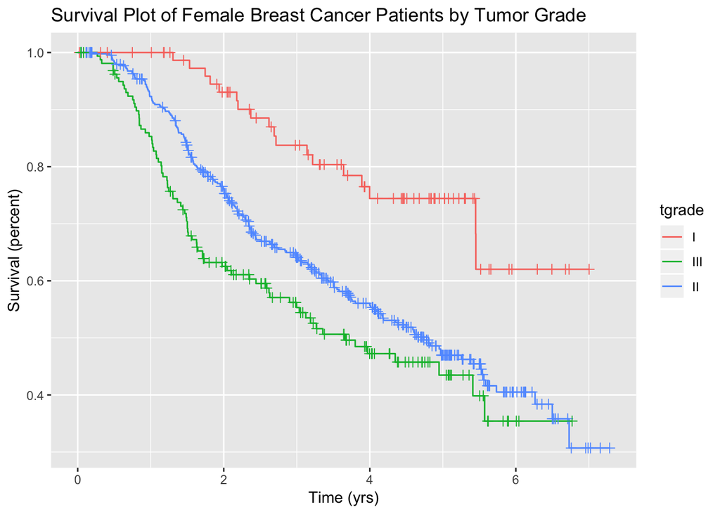

```r
gbsg_surv <- survival::survfit(Surv(time_yrs, cens) ~ tgrade, data = gbsg2)
ggsurv(gbsg_surv,
       main = "Survival Plot of Female Breast Cancer Patients by Tumor Grade",
       xlab = "Time (yrs)",
       ylab = "Survival (percent)")
```

### Build Models

Let’s explore different models from linear discriminate analysis to random forest and see which one provides us the most accurate prediction.

For some context:

```r
# Break up sample into train and test
# set.seed(123)
# assignment <- sample(1:2, nrow(gbsg2), prob = c(0.7, 0.3), replace = T)

# Alternative method of sampling
train_index <- createDataPartition(gbsg2$cens, p = 0.8, list = F)
gbsg2_train <- gbsg2[train_index,] %>% select(-cens)
gbsg2_test <- gbsg2[-train_index,] %>% select(-cens)

# add groups to gbsg2 tibble
# gbsg2 <- gbsg2 %>% mutate(group = assignment)
# gbsg2_train <- gbsg2 %>% filter(group == 1)
# gbsg2_test <- gbsg2 %>% filter(group == 2)

# Setup 10-fold cross validation
control <- trainControl(method = "cv", number = 10)
metric <- "Accuracy"

# a) linear algorithms
set.seed(7)
fit.lda <- train(cens_fct ~ ., data = gbsg2_train, method = "lda", metric = metric, trControl = control)

# b) nonlinear algorithms
# CART
set.seed(7)
fit.cart <- train(cens_fct ~ ., data = gbsg2_train, method = "rpart", metric = metric, trControl = control)
# kNN
set.seed(7)
fit.knn <- train(cens_fct ~ ., data = gbsg2_train, method = "knn", metric = metric, trControl = control)

# c) advanced algorithms
# SVM
set.seed(7)
fit.svm <- train(cens_fct ~ ., data = gbsg2_train, method = "svmRadial", metric = metric, trControl = control)
# Random Forest
set.seed(7)
fit.rf <- train(cens_fct ~ ., data = gbsg2_train, method = "rf", metric = metric, trControl = control)

# summarize accuracy of models
results <- resamples(list(lda = fit.lda, cart = fit.cart, knn = fit.knn, svm = fit.svm, rf = fit.rf))
summary(results)
```

```
##
## Call:
## summary.resamples(object = results)
##
## Models: lda, cart, knn, svm, rf
## Number of resamples: 10
##
## Accuracy
##           Min.   1st Qu.    Median      Mean   3rd Qu.      Max. NA's
## lda  0.5636364 0.6679293 0.7363636 0.7175421 0.7590909 0.9090909    0
## cart 0.5090909 0.6866162 0.7181818 0.6976094 0.7590909 0.8000000    0
## knn  0.6363636 0.6668350 0.7272727 0.7103704 0.7454545 0.7636364    0
## svm  0.5818182 0.6941077 0.7363636 0.7303704 0.7636364 0.9090909    0
## rf   0.5818182 0.6804714 0.7272727 0.7249158 0.7772727 0.8363636    0
##
## Kappa
##             Min.   1st Qu.    Median      Mean   3rd Qu.      Max. NA's
## lda   0.06911142 0.3283329 0.4568511 0.4210834 0.5073166 0.8143147    0
## cart -0.03196664 0.3260872 0.4291687 0.3764311 0.5001615 0.5795691    0
## knn   0.23928077 0.3239599 0.4222647 0.3997921 0.4713262 0.5126108    0
## svm   0.11228070 0.3659052 0.4532583 0.4430262 0.5126108 0.8125426    0
## rf    0.12091730 0.3430772 0.4292807 0.4312651 0.5459379 0.6593255    0
```

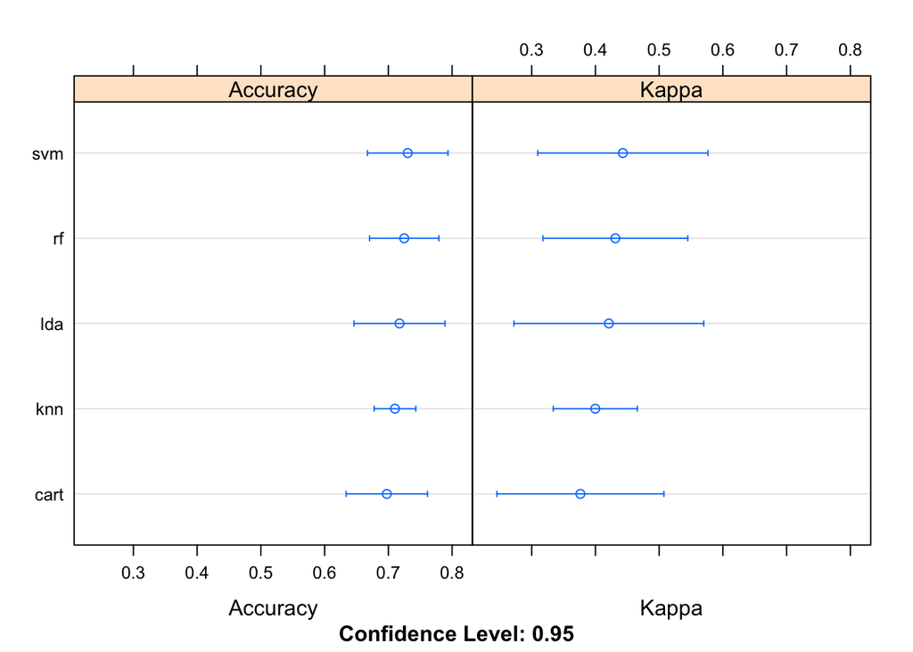

```r
dotplot(results)
```

```r
print(fit.rf)
```

```
## Random Forest
##
## 549 samples
##  10 predictor
##   2 classes: '0', '1'
##
## No pre-processing
## Resampling: Cross-Validated (10 fold)
## Summary of sample sizes: 494, 494, 494, 494, 494, 494, ...
## Resampling results across tuning parameters:
##
##   mtry  Accuracy   Kappa
##    2    0.7249158  0.4312651
##    6    0.7104377  0.3972869
##   11    0.7049158  0.3863489
##
## Accuracy was used to select the optimal model using the largest value.
## The final value used for the model was mtry = 2.
```

```r
# estimate skill of RF on the validation dataset
predictions <- predict(fit.rf, gbsg2_test)
confusionMatrix(predictions, gbsg2_test$cens_fct)
```

```
## Confusion Matrix and Statistics
##
##           Reference
## Prediction  0  1
##          0 61 21
##          1 13 42
##
##                Accuracy : 0.7518
##                  95% CI : (0.6708, 0.8216)
##     No Information Rate : 0.5401
##     P-Value [Acc > NIR] : 2.608e-07
##
##                   Kappa : 0.4957
##
##  Mcnemar's Test P-Value : 0.2299
##
##             Sensitivity : 0.8243
##             Specificity : 0.6667
##          Pos Pred Value : 0.7439
##          Neg Pred Value : 0.7636
##              Prevalence : 0.5401
##          Detection Rate : 0.4453
##    Detection Prevalence : 0.5985
##       Balanced Accuracy : 0.7455
##
##        'Positive' Class : 0
##
```